# Midterm_03

王韵倫

2017.1.19 [278期]

##### Midterm_03為R程式設計班[278期]第三項作業。其中，將以GitHub Pages呈現ggplot2繪製五種圖形、R markdown撰寫報告之練習結果。

## 使用Toy datasets說明

本次報告所使用之Toy datasets如下：

- women：美國女性平均身高與體重，樣本數為15。(in package “datasets”)
- trees：黑櫻桃樹之周長、高度和體積，樣本數為31。(in package “datasets”)
- sleep：兩組學生額外睡眠時間，各組樣本數為10。(in package “datasets”)
- msleep：哺乳動物睡眠相關資料，樣本數為83。(in package “ggplot2”)

## 1. 散佈圖 與 線圖之習作

### 美國女性平均身高與體重比較

#### 1.1 Toy dataset - “women”呈現

Average Heights and Weights for American Women

```
##    height weight
## 1      58    115
## 2      59    117
## 3      60    120
## 4      61    123
## 5      62    126
## 6      63    129
## 7      64    132
## 8      65    135
## 9      66    139
## 10     67    142
## 11     68    146
## 12     69    150
## 13     70    154
## 14     71    159
## 15     72    164
```

#### 1.2 圖表呈現

根據1.1資料表內數據，對美國女性平均身高與體重進行**散佈圖**繪製

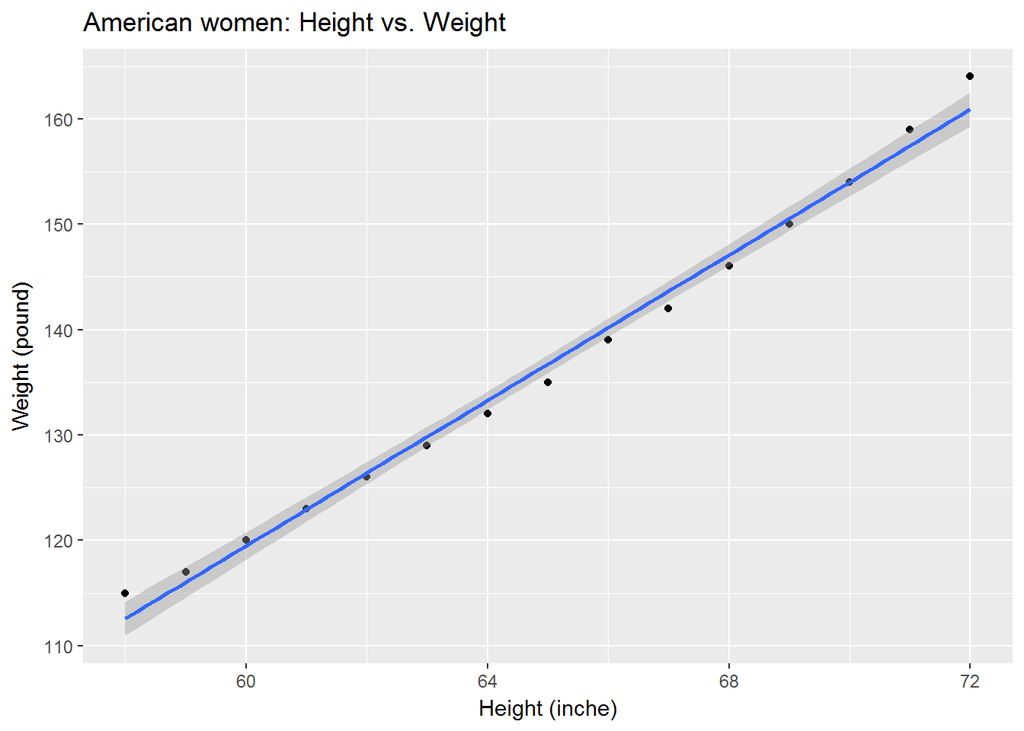

```r
library("ggplot2", lib.loc="~/R/win-library/3.3")
ggplot(women,aes(x=height,y=weight)) +
  geom_point() +
  ggtitle("American women: Height vs. Weight") +
  xlab("Height (inche)") +
  ylab("Weight (pound)") +
  geom_smooth(method = "lm")
```

由此可推測，上圖對應之**線圖**如下：

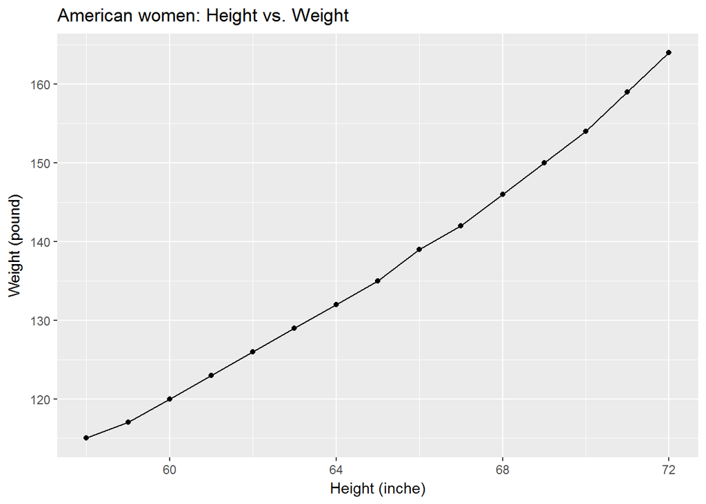

```r
library("ggplot2", lib.loc="~/R/win-library/3.3")
ggplot(women,aes(x=height,y=weight)) +
  geom_point() +
  ggtitle("American women: Height vs. Weight")+
  xlab("Height (inche)")+
  ylab("Weight (pound)")+
  geom_line()
```

為了不要讓報告太空虛，我們就總結，在本次觀測樣本數為15的美國女性數據中，其身高與體重呈現正向關係。

## 2. 直方圖之習作

### 黑櫻桃樹周長分佈

#### 2.1 Toy dataset - “trees”呈現

Girth, Height and Volume for Black Cherry Trees (Summary)

```
##      Girth           Height       Volume
##  Min.   : 8.30   Min.   :63   Min.   :10.20
##  1st Qu.:11.05   1st Qu.:72   1st Qu.:19.40
##  Median :12.90   Median :76   Median :24.20
##  Mean   :13.25   Mean   :76   Mean   :30.17
##  3rd Qu.:15.25   3rd Qu.:80   3rd Qu.:37.30
##  Max.   :20.60   Max.   :87   Max.   :77.00
```

#### 2.2 圖表呈現

根據2.1資料表內數據，對黑櫻桃樹周長進行**直方圖**繪製

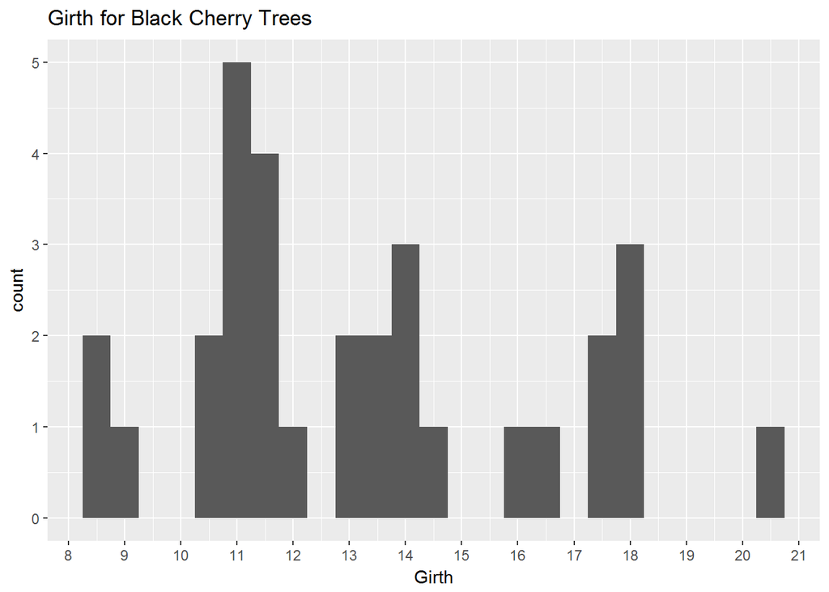

```r
library("ggplot2", lib.loc="~/R/win-library/3.3")
ggplot(trees, aes(x = Girth)) +
  geom_histogram(binwidth = 0.5) +
  scale_x_continuous(breaks=seq(8, 21, 1)) +
  ggtitle("Girth for Black Cherry Trees")
```

## 3. 盒鬚圖之習作

### 統計兩組學生額外睡眠時間

#### 3.1 Toy dataset - “sleep”呈現

Student’s Sleep Data (Summary)

```
##      extra        group        ID
##  Min.   :-1.600   1:10   1      :2
##  1st Qu.:-0.025   2:10   2      :2
##  Median : 0.950          3      :2
##  Mean   : 1.540          4      :2
##  3rd Qu.: 3.400          5      :2
##  Max.   : 5.500          6      :2
##                          (Other):8
```

#### 3.2 圖表呈現

根據3.1資料表內數據，對兩組學生睡眠時間進行**盒鬚圖**繪製

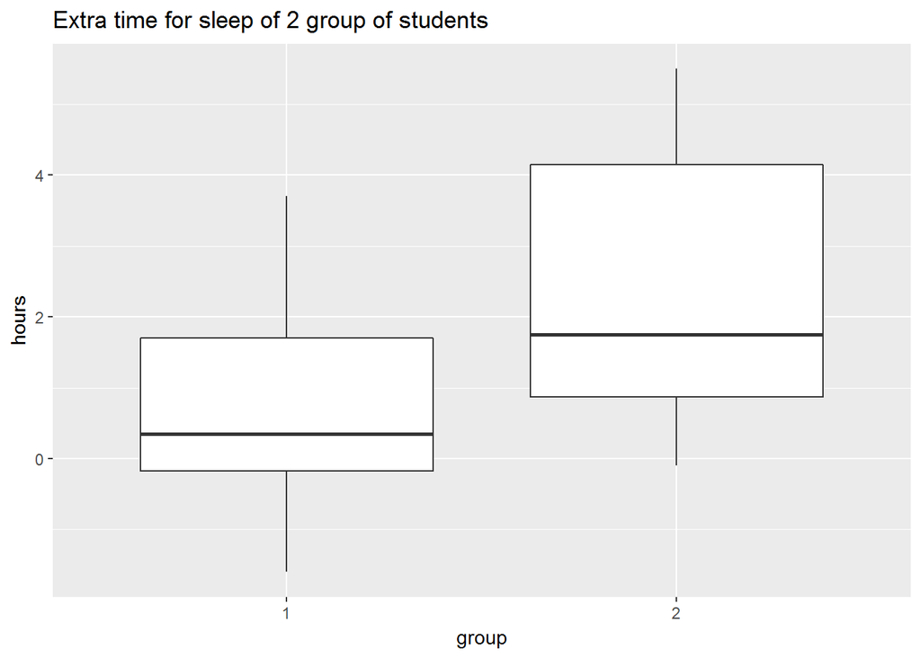

```r
library("ggplot2", lib.loc="~/R/win-library/3.3")
ggplot(sleep, aes(x = group, y = extra)) +
  geom_boxplot() +
  ggtitle("Extra time for sleep of 2 group of students") +
  ylab("hours")
```

總結，雖然資料表中數據有負數，但大致上兩組學生熬夜現象甚小；另外，第二組學生額外睡眠時間較長（平均數較大），且彼此差異較大。

## 4. 長條圖之習作

### 哺乳動物睡眠時間之比較

#### 4.1 Toy dataset - “msleep”呈現

An updated and expanded version of the mammals sleep dataset (Summary)

```
##      name              genus               vore
##  Length:83          Length:83          Length:83
##  Class :character   Class :character   Class :character
##  Mode  :character   Mode  :character   Mode  :character
##
##
##
##
##     order           conservation        sleep_total      sleep_rem
##  Length:83          Length:83          Min.   : 1.90   Min.   :0.100
##  Class :character   Class :character   1st Qu.: 7.85   1st Qu.:0.900
##  Mode  :character   Mode  :character   Median :10.10   Median :1.500
##                                        Mean   :10.43   Mean   :1.875
##                                        3rd Qu.:13.75   3rd Qu.:2.400
##                                        Max.   :19.90   Max.   :6.600
##                                                        NA's   :22
##   sleep_cycle         awake          brainwt            bodywt
##  Min.   :0.1167   Min.   : 4.10   Min.   :0.00014   Min.   :   0.005
##  1st Qu.:0.1833   1st Qu.:10.25   1st Qu.:0.00290   1st Qu.:   0.174
##  Median :0.3333   Median :13.90   Median :0.01240   Median :   1.670
##  Mean   :0.4396   Mean   :13.57   Mean   :0.28158   Mean   : 166.136
##  3rd Qu.:0.5792   3rd Qu.:16.15   3rd Qu.:0.12550   3rd Qu.:  41.750
##  Max.   :1.5000   Max.   :22.10   Max.   :5.71200   Max.   :6654.000
##  NA's   :51                       NA's   :27
```

#### 4.2 圖表呈現

根據4.1資料表內數據，對各種哺乳動物一天總睡眠時間進行**長條圖**繪製

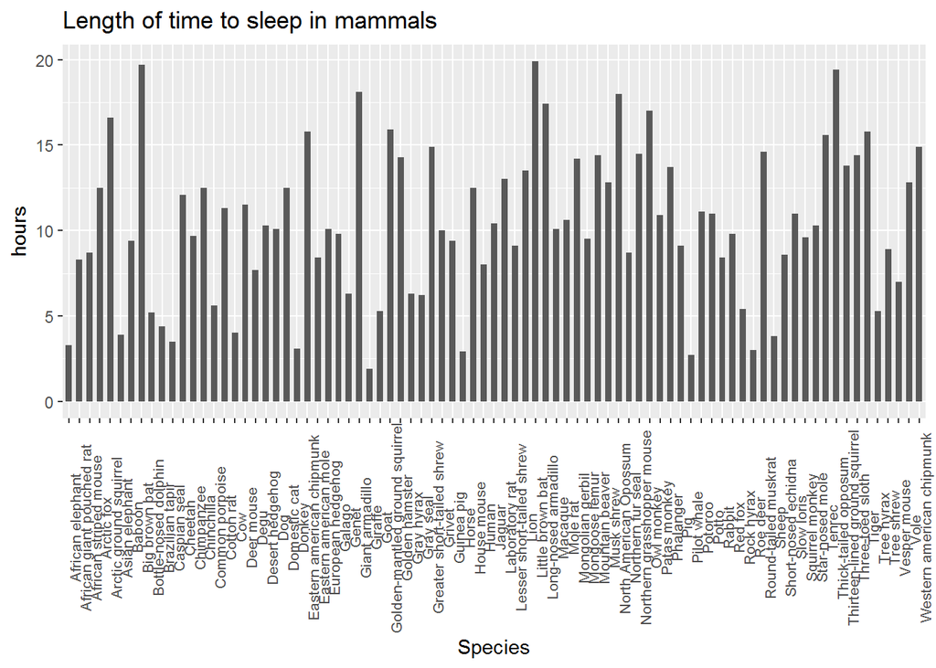

```r
library("ggplot2", lib.loc="~/R/win-library/3.3")
ggplot(msleep, aes(x= name,y= sleep_total)) +
  ggtitle("Length of time to sleep in mammals") +
  xlab("Species") +
  ylab("hours") +
  geom_bar(stat = "identity",width = 0.6) +
  theme(axis.text.x = element_text(size = 8,angle = 90))
```

總結，哺乳動物中，總睡眠時間最短之生物為Giraffe，一天共睡1.9小時；時間最長的為[Little brown bat](https://en.wikipedia.org/wiki/Little_brown_bat)，則一天共睡19.9小時。